# Venice is drowning - final report

# Premesse

L’obiettivo principale del progetto proposto è sostanzialmente quello di analizzare i dati delle rilevazioni di marea per quanto riguarda l’area della laguna di Venezia con lo scopo di realizzare e testare dei modelli predittivi, valutati su un orizzonte temporale che va da un’ora fino ad una settimana di previsione.

A questo scopo i modelli realizzati sono tre, due lineari ed uno di machine learning:

- un modello ARIMA (AutoRegressive Integrated Moving Average);
- un modello UCM (Unobserved Component Models);
- un modello LSTM (Long Short-Term Memory).

# Datasets

I dataset utilizzati per lo svolgimento della pipeline del progetto sono sostanzialmente due: un primo dataset composto dalle rilevazioni, tramite un apposito sensore, dei livelli di marea nella laguna di Venezia in cm rispetto ad un certo valore di riferimento dal 1983 fino al 2018 mentre il secondo contiene le informazioni riguardanti variabili meteorologiche (precipitazioni in millimetri, direzione del vento in gradi, velocità del vento in Km/h) dal 2000 al 2019.

Il dataset dei livelli di marea è stato composto dai singoli dataset storici annuali forniti dal Comune di Venezia, in particolare dal [Centro Previsioni e Segnalazioni Maree](https://www.comune.venezia.it/node/6214). I dati riguardanti invece le variabili meteorologiche sono stati forniti, su richiesta, da [ARPA Veneto](https://www.arpa.veneto.it/). Tutte le operazioni di preprocessing riguardanti l’assemblaggio, l’ispezione e la conclusiva unione dei dataset citati sono disponibili nei seguenti script/html realizzati con questo ordine:

- **parsing_tides_data** è lo script utilizzato per svolgere l’operazione di assemblaggio del dataset delle maree completo, importando ed unificando tutti i dataset annuali disponibili;
- **inspection** contiene una serie di ispezioni preliminari rispetto i dati citati;
- **preprocess_weather_data_2000_2019** contiene invece le operazioni di processing riguardanti i dati meteorologici;
- **parsing_tides_weather** riassume infine le operazioni svolte per risolvere il problema dei dati mancanti per quanto riguarda il dataset dei dati meteorologici ed il finale *merge* dei due file.

Come scelta progettuale, si è deciso in fase di processing dei dati di limitare l’utilizzo di questi al periodo tra Gennaio 2010 e Dicembre 2018.

# Panoramica

Durante la fase di processing dei dati e prima di procedere all’effettiva realizzazione dei modelli di previsione, sono state prodotte una serie di visualizzazioni con lo scopo di ispezionare a fondo alcuni aspetti riguardanti la serie storica.

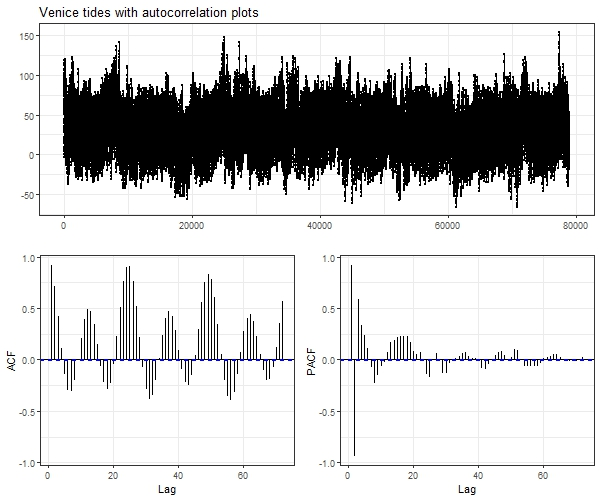

Figure 1: Visualizzazione della serie storica con relativi plot di autocorrelazione

In fig. 1 è possibile osservare la serie storica completa, rappresentata insieme ai plot di autocorrelazione ed autocorrelazione parziale, mentre in fig. 2 si può verificare come il fenomeno delle maree sembrerebbe distribuirsi seguendo una distribuzione normale. In questo caso, infatti, i concetti di stazionarietà debole e forte si equivalgono.

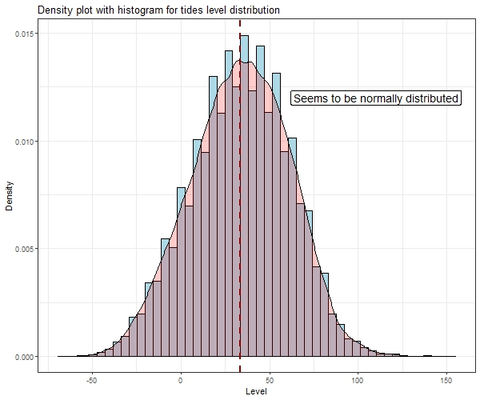

Figure 2: Distribuzione dei valori della serie storica

Durante il lavoro di prima ispezione dei dati storici una delle verifiche effettuate ha riguardato la stazionarietà in media e quella in varianza: per quanto riguarda la prima osservando la serie in fig. 1 questa sembrerebbe effettivamente risultare stazionaria in media, per questa ragione per confermare l’ipotesi di stazionarietà in fig. 3 è riportato l’output di un test Augmented Dickey-Fuller che, come si vede, conferma a tutti gli effetti la stazionarietà in media del fenomeno mareale.

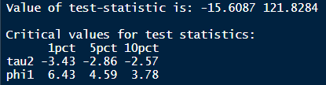

Figure 3: output test ADF

Successivamente alla verifica della stazionarità in media si è proceduto a verificare la stazionarietà in varianza: appare chiaro dal plot riportato in fig. 4 come i valori medi di marea per giorno e la loro *standard deviation* non risultino in un trend crescente ma anzi seguano sostanzialmente un trend piatto.

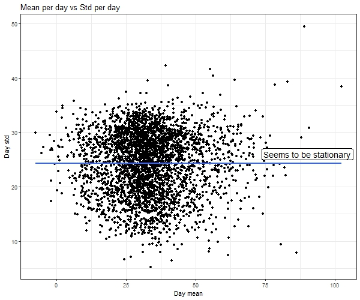

Figure 4: Verifica stazionarietà in varianza

# Modelli

- per i modelli lineari il training set consiste negli ultimi sei mesi del 2018, a partire da Luglio fino a Dicembre 2018;
- per il modello machine learning, data la sua capacità di gestire moli di dati decisamente superiori a parità di tempo di computazione, come training set è stato utilizzato tutto il dataset a partire da Gennaio 2010 fino a Dicembre 2018.

Il test set, estratto a priori, consiste nell’ultima settimana di Dicembre 2018, ovvero dal 24/12/2018 23:00:00 al 31/12/2018 alle 23:00:00.

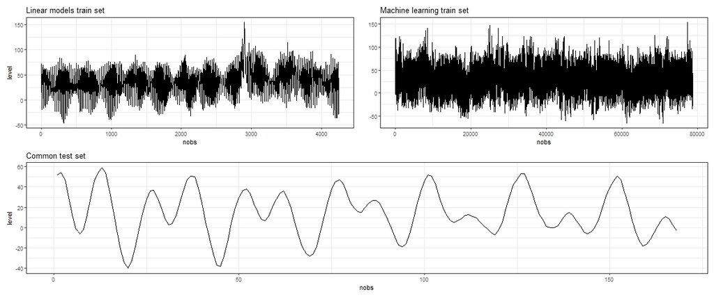

Figure 5: Rappresentazione dei dati di train e di test

## Modelli lineari

Entrambi i modelli lineari realizzati, come detto, utilizzano come training set i dati delle maree a partire dal 01/07/2018 00:00:00 fino al 24/12/2018 23:00:00. Questa scelta è stata guidata da esigenze di ottimizzazione dei tempi di *fitting* dei modelli poichè, selezionando più dati, si è riscontrato un importante dilatamento di questi. Sia ARIMA che UCM sono stati scritti in R, utilizzando a questo scopo i pacchetti *forecast* e *KFAS*.

## Machine Learning

Dario Bertazioli, Fabrizio D’Intinosante

2020-01-21